# MÍNIMOS CUADRADOS PONDERADOS (WEIGHTED LEAST SQUARE)

JOSÉ M. GÓMEZ

8/11/2021

```r
load("presang.Rdata")
attach(base)
```

# MÍNIMOS CUADRADOS PONDERADOS

Como señalan (Gujarati & Porter. Econometría, 2009. p. 371), los estimadores usuales de mínimos cuadrados ordinarios (MCO) de algún coeficiente $β_i$ pueden en ocasiones no ser los mejores estimadores, aunque sean insesgados. Ello ocurre en el escenario en que la relación entre la respuesta y el o los predictores presentan gran variabilidad, *i.e.*, en aquellos donde el supuesto de homogeneidad de varianza es claramente incumplido. En tales casos, al efectuar una regresión, es recomendable aprovechar el conocimiento que se posee sobre dicha variabilidad. Idealmente es deseable diseñar un esquema de estimación de manera tal que las observaciones que surgen de poblaciones con mayor variabilidad reciban menos peso que las que provienen de poblaciones con menor variabilidad, pues las primeras están más concentradas alrededor de sus valores medios que las últimas, lo que permite estimar la función de regresión poblacional (FRP) en forma más precisa. Sin embargo, el método de MCO usual no sigue esta estrategia y, por consiguiente, no aprovecha la “información” contenida en la variabilidad desigual de la variable dependiente Y: este método asigna igual peso o importancia a cada observación. Pero existe un método de estimación, conocido como mínimos cuadrados generalizados (MCG), que toma en cuenta esa información explícitamente y, por consiguiente, es capaz de producir estimadores que son MELI.

Como señala (Nataniel Greene, Generalized Least-Squares Regressions V: Multiple Variables, p.1; https://academicworks.cuny.edu/cgi/viewcontent.cgi?article=1079&context=kb_pubs), en términos geométricos y de poder determinar unívocamente cuáles son los mejores estimadores entre la clase de estimadores insesgados, el hecho de que existan m + 1 hiperplanos MCO para modelar un solo conjunto de datos en m + 1 variables es problemático. Se desea por consiguiente tener un modelo lineal único para los datos, para el cual es válido resolver para cualquiera de las variables con fines de predicción. Los mínimos cuadrados generalizados multivariados resuelven este problema buscando minimizar la media generalizada promedio (del inglés “average generalized mean”, que es una generalización de todos los tipos de media conocida también como *media de Hölder*, cuya siguiente y máxima generalización es la *media cuasi-aritmética* o *media de Kolmogórov*, es equivalente conceptualmente a la media aritmética en este contexto; al hablar de una media generalizada “promedio” hace referencia a la división del estadístico entre el número de observaciones durante el proceso de estimación) de las desviaciones cuadradas entre los datos y el hiperplano en todas las variables simultáneamente. Para el hiperplano de regresión resultante, es válido resolver cualquiera de las variables con fines de predicción.

Como señalan (Gujarati & Porter. Econometría, 2009. p. 373), el término de error estocástico de los MCO se transforma en el escenario MCG en una suma ponderada de residuos al cuadrado donde $w_i=1/σ_i^2$ actúan como ponderación, tal como se presenta a continuación:

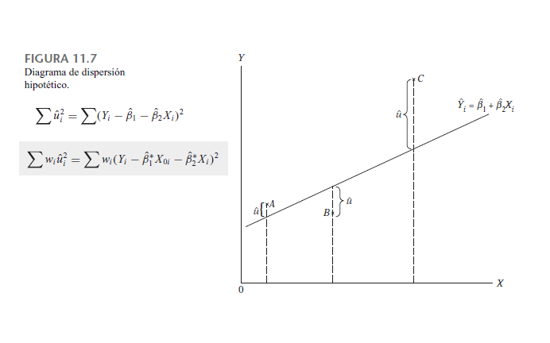

```r
knitr::include_graphics("F1.png")
```

```r
#Figura 1: Mínimos Cuadrados Generalizados (MCG)
#Fuente: Gujarati & Porter. Econometría, 2009. p. 373-374.
```

Como puede observarse, en MCO se reduce la SCR sin ponderar o (lo que equivale a lo mismo) con ponderaciones iguales. Como muestra la figura 1, en MCG, el peso asignado a cada observación es inversamente proporcional a su $σ_i$, es decir, las observaciones que provienen de una población con una $σ_i$ más grande tendrán una ponderación relativamente menor, y las de una población con un σi menor tendrán una ponderación proporcionalmente mayor al reducir la SCR.

Como se señala en la fuente referida (p. 376), aunque ya se estableció que, en caso de heteroscedasticidad, son los MCG y no los MCO los que son MELI, existen ejemplos en los que los MCO pueden ser MELI a pesar de la heteroscedasticidad. No obstante, dichos casos son poco frecuentes en la práctica y su existencia obedece a que el teorema de Gauss-Markov proporciona la condición suficiente (pero no necesaria) para que los MCO sean efi cientes. La condición suficiente y necesaria para que los MCO sean MELI la establece el teorema de Kruskal. Para mayores detalles, véase Denzil G. Fiebig, Michael McAleer y Robert Bartels, “Properties of Ordinary Least Squares Estimators in Regression Models with Nonspherical Disturbances”, Journal of Econometrics, vol. 54, núm. 1-3, octubre-diciembre de 1992, pp. 321-334.

Como se señala en https://www.wikiwand.com/en/Generalized_least_squares, un caso especial de los MCG llamado mínimos cuadrados ponderados (MCP) ocurre cuando todas las entradas fuera de la diagonal de la matriz de covarianzas $Ω$ son 0. Esta situación surge cuando las varianzas de los valores observados son desiguales (es decir, hay heterocedasticidad presente), pero donde no existen correlaciones entre las variaciones observadas. El peso de la unidad $i$ es proporcional al recíproco de la varianza de la respuesta de la unidad $i$.

Si se desconoce la covarianza de los errores $Ω$, se puede obtener una estimación coherente $Ω$, digamos $\hat\Omega$, utilizando una versión implementable de GLS conocida como estimador de mínimos cuadrados generalizados factibles (MCGF). En MCGF, el modelado procede en dos etapas: (1) el modelo es estimado por MCO u otro estimador consistente (pero ineficiente), y los residuales se usan para construir un estimador consistente de la matriz de covarianza de errores (para hacerlo, a menudo se necesita para examinar el modelo agregando restricciones adicionales, por ejemplo, si los errores siguen un proceso de series de tiempo, un estadístico generalmente necesita algunos supuestos teóricos sobre este proceso para asegurarse de que esté disponible un estimador consistente); y (2) utilizando el estimador consistente de la matriz de covarianza de los errores, se pueden implementar ideas MCG.

Mientras que MCG es más eficiente que OLS bajo heterocedasticidad o autocorrelación, esto no es cierto para MCGF. El estimador factible es, siempre que la matriz de covarianza de errores se calcule de manera consistente, asintóticamente más eficiente, pero para una muestra de tamaño pequeño o mediano, en realidad puede ser menos eficiente que MCO. Por eso, algunos autores prefieren utilizar MCO y reformular sus inferencias simplemente considerando un estimador alternativo para la varianza del estimador robusto a la heteroscedasticidad o autocorrelación en serie. Pero para muestras grandes se prefiere FGLS sobre MCO bajo heterocedasticidad o correlación serial. Una nota de advertencia es que el estimador MCGF no siempre es consistente. Un caso en el que MCGF podría ser inconsistente es si hay efectos fijos específicos individuales.

En general, este estimador (el MCGF) tiene propiedades diferentes a MCG. Para muestras grandes (es decir, asintóticamente) todas las propiedades son (en condiciones apropiadas) comunes con respecto a GLS, pero para muestras finitas se desconocen las propiedades de los estimadores MCGF: varían dramáticamente con cada modelo en particular y, como regla general, sus distribuciones exactas. no se puede derivar analíticamente. Para muestras finitas, MCGF puede ser incluso menos eficiente que OLS en algunos casos. Por lo tanto, aunque GLS puede ser factible, no siempre es prudente aplicar este método cuando la muestra es pequeña. Un método que a veces se usa para mejorar la precisión de los estimadores en muestras finitas es iterar, es decir, tomar los residuales de MCGF para actualizar el estimador de covarianza de errores y luego actualizar la estimación de MCGF, aplicando la misma idea de manera iterativa hasta que los estimadores varíen menos que algunos. tolerancia. Pero este método no necesariamente mejora mucho la eficiencia del estimador si la muestra original era pequeña. Una opción razonable cuando las muestras no son demasiado grandes es aplicar MCO, pero descartando el estimador de varianza clásico $σ^2*(X' X)^{(-1)}$ (que es inconsistente en este marco) y usando un estimador HAC (Heteroscedasticidad y Autocorrelación Consistente).

Como señalan (Gujarati & Porter. Econometría, 2009. p. 447), es importante observar que siempre que se estimen los parámetros del modelo transformado con un método MCGF o un MCGE, los coeficientes estimados no necesariamente tendrán las propiedades óptimas usuales del modelo clásico, como ser MELI, sobre todo en muestras pequeñas. Sin adentrarnos en complejidades técnicas, podemos enunciar, como principio general, que siempre que se utilice un estimador en lugar de su verdadero valor, los coeficientes de MCO estimados quizá presenten las propiedades óptimas usuales en forma asintótica; es decir, para muestras grandes. Asimismo, los procedimientos convencionales para pruebas de hipótesis son, en estricto sentido, válidos de modo asintótico. En consecuencia, para muestras pequeñas, se debe tener cuidado al interpretar los resultados estimados. En cuarto lugar, al utilizar MCGF, si no se incluye la primera observación (como se hace, por ejemplo, en el método Cochrane-Orcutt), se pueden ver afectados de modo adverso no sólo los valores numéricos, sino también la eficiencia de los estimadores, sobre todo si el tamaño de la muestra es pequeño y las regresoras no son, estrictamente hablando, no estocásticas (esto es especialmente cierto si las regresoras muestran una tendencia, lo cual es muy común en los datos económicos).

# CASO DE APLICACIÓN: PREDICCIÓN DE LA PRESIÓN SANGUÍNEA

Se toman 54 mujeres adultas entre 20 y 60 años y se les mide la presión sanguínea diastólica para ver su relación con la edad, el único predictor.

Con ellos puede estimarse un modelo de regresión que tenga como respuesta **Presion** y como predictor **Edad**. Es recomendable elaborar gráficos de los residuales y de los residuales al cuadrado contra edad, con la finalidad de estudiar el comportamiento de la varianza residual.

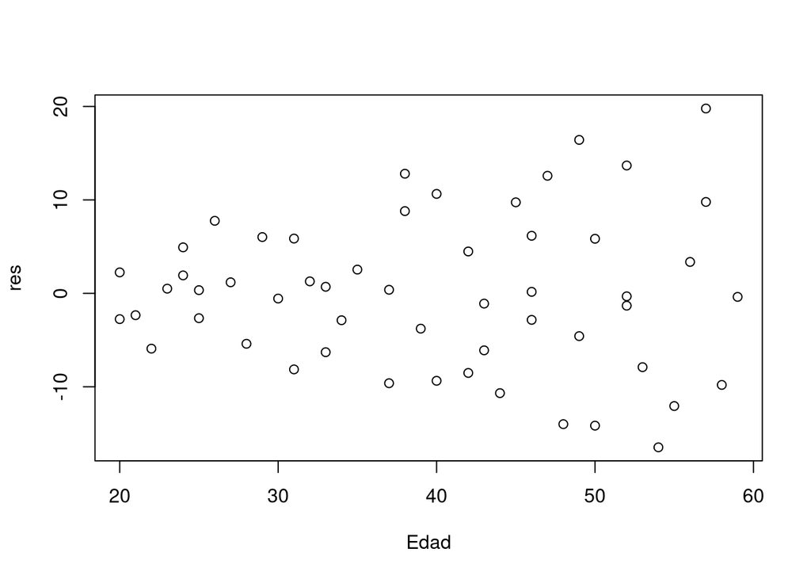

```r
mod=lm(Presion~Edad,base)
res=mod$res
plot(Edad,res)
```

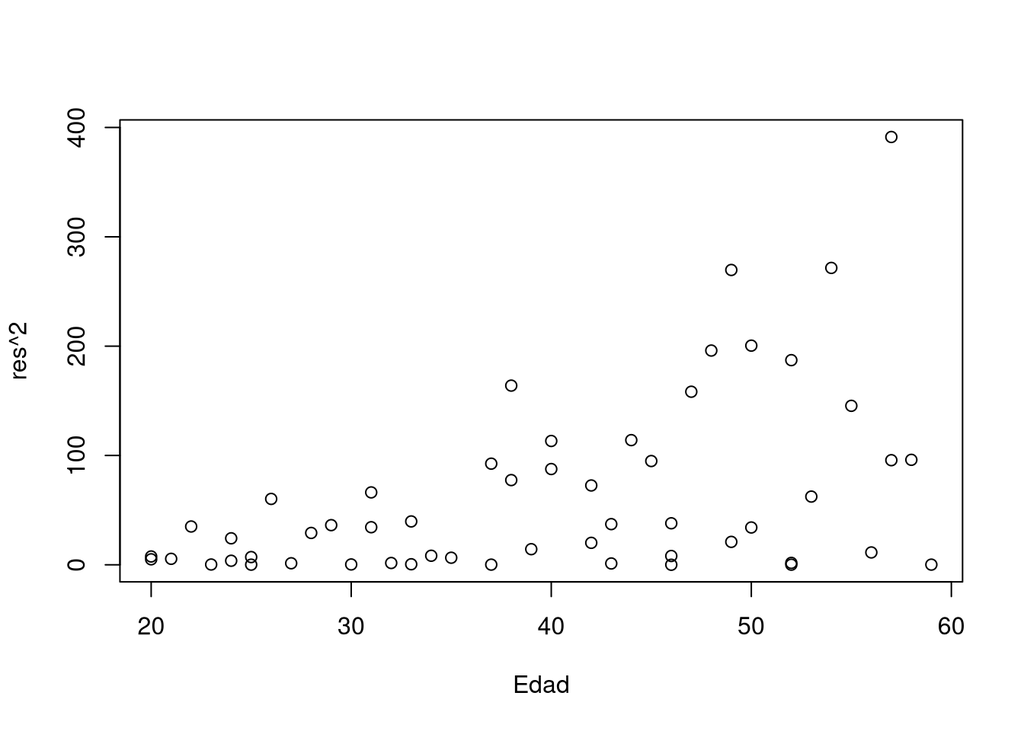

```r
plot(Edad,res^2)
```

Puesto que en el gráfico de los residuales contra la edad tiene forma de megáfono, se sugiere encontrar la función de desviación estándar al ajustar el modelo de residuales absolutos contra edad. El segundo gráfico muestra una tendencia creciente por lo que se puede encontrar la función de variancia al ajutar el modelo de residuales cuadráticos contra edad.

En términos de lo antes expuesto, debe estimarse un modelo de desviación estándar poniendo como respuesta los residuales absolutos y como predictor la edad, tras lo cual deben encontrarse los valores estimados en este modelo y tomarse como las desviaciones estándar en la construcción de los pesos. El vector de ponderaciones $w_i$ se construye tal que
$$w_i=\frac{1}{\hat{s}_i^2}$$
.

```r
modres1=lm(abs(res)~Edad)
s=predict(modres1)
w=1/(s^2)
```

Para realizar el ajuste vía mínimos cuadrados ponderados es necesario construir la matriz $W$. Ello puede lograrse almacenando los pesos en una matriz diagonal (una matriz cuyos elementos fuera de la diagonal son ceros). Si $w$ es el vector de ponderaciones o pesos, entonces `W=diag(w)` es la matriz diagonal.

```r
W=diag(w)
```

Habiendo construido la matriz $W$ puede realizarse la estimación de los coeficientes de regresión mediante:
$$\hat{\beta}^{(w)}=(X^TWX)^{-1}(X^TWY)$$

```r
y=Presion
x=cbind(1,Edad)
bw=solve(t(x) %*% W %*% x) %*% (t(x) %*% W %*% y)
round(bw,2)
```

```
##       [,1]
##      55.57
## Edad  0.60
```

Adicionalmente, puede estimarse un modelo de la varianza en el que se establezca como respuesta a los residuales cuadráticos y como predictor la edad. Tras encontrarse los valores estimados en el modelo antes descrito, estos deben tomarse como las varianzas en la construcción de los pesos.

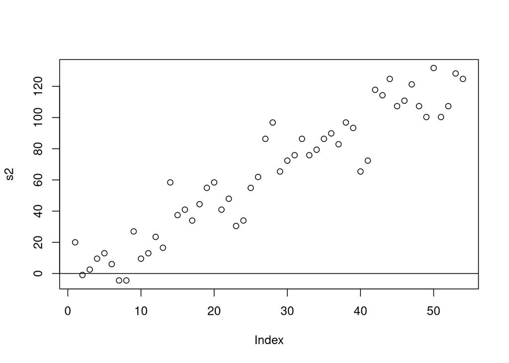

```r
res2=res^2
modres2=lm(res2~Edad)
s2=predict(modres2)
plot(s2)
abline(h=0)
```

El lector puede observar que algunas estimaciones son negativas, por lo que no son adecuadas como estimaciones de las varianzas (puesto que esta es por definición positiva, dado que no existen distancias negativas y la varianza no es más que la distancia cuadrática que existe entre una observación y la media), por lo que no debe continuarse con este camino.

Además, pueden compararse los coeficientes obtenidos en el modelo sin ponderar y en el modelo que considera las ponderaciones.

```r
round(cbind(mod$coef,bw),2)
```

```
##              [,1]  [,2]
## (Intercept) 56.16 55.57
## Edad         0.58  0.60
```

Es de especial interés la comparación entre el CMR (el cuadrado medio residual, que es el resultado de dividir la suma de cuadrados totales residuales entre los grados de libertad n-p) del modelo original sin poderar con el del modelo ponderado, en donde en el segundo caso se encuentra mediante
$$CMR^{(w)}=\frac{\sum w_i
(y_i-\hat{y}_i)^2}{n-p}$$
.

```r
cmres=anova(mod)[2,3]
n=nrow(base)
p=2
fitw=x%*%bw
resw=y-fitw
scresw=sum(w*resw^2)
cmresw=scresw/(n-p)
c(cmres,cmresw)
```

```
## [1] 66.353173  1.471414
```

La matriz de covarianzas de los coeficientes de regresión se determina mediante la ecuación
$$\hat{V}(\hat{\beta}^{(w)})=CMR^{(w)}
(X^TWX)^{-1}$$

```r
vcovw=cmresw*solve(t(x) %*% W %*% x)
vcovw
```

```
##                         Edad
##       6.3550256 -0.189363636
## Edad -0.1893636  0.006278666
```

Podría ser de interés para el investigador comparar el error estándar del coeficiente para *edad* obtenido sin ponderar con el que se obtiene en el escenario ponderado.

```r
sqrt(vcov(mod)[2,2])
```

```
## [1] 0.09695116
```

```r
sqrt(vcovw[2,2])
```

```
## [1] 0.07923803
```

La respuesta media ponderada (el valor esperado ponderado de la respuesta) puede encontrarse mediante la ecuación
$$\bar{y}^{(w)}=\frac{\sum w_i y_i}{\sum
w_i}$$
.

```r
medw=sum(w*y)/sum(w)
medw
```

```
## [1] 73.55134
```

También puede calcularse la suma de cuadrados total ponderada mediante la siguiente ecuación:
$$SCT^{(w)}=\sum w_i
(y_i-\bar{y}^{(w)})^2$$

```r
sctw=sum(w*(y-medw)^2)
sctw
```

```
## [1] 159.8543
```

Tras esto, puede también obtenerse el $R^2$ ponderado mediante
$$R^2_{(w)}=1-\frac{SCRes^{(w)}}{SCTot^{(w)}}$$
.

```r
r2w=1-scresw/sctw
r2w
```

```
## [1] 0.5213548
```

Es de especial interés la comparación entre el $R^2$ obtenido sin ponderar y el ponderado.

```r
r2=summary(mod)$r.sq
round(c(r2,r2w),2)
```

```
## [1] 0.41 0.52
```

Finalmente, pueden obtenerse todos los resultados anteriores de forma automatizada mediante la sintaxis `lm` indicando el vector de ponderaciones en el argumento `weigths=w`.

```r
modw=lm(Presion~Edad, weights = w)
summary(modw)
```

```
##
## Call:
## lm(formula = Presion ~ Edad, weights = w)
##
## Weighted Residuals:
##     Min      1Q  Median      3Q     Max
## -2.0230 -0.9939 -0.0327  0.9250  2.2008
##
## Coefficients:
##             Estimate Std. Error t value Pr(>|t|)
## (Intercept) 55.56577    2.52092  22.042  < 2e-16 ***
## Edad         0.59634    0.07924   7.526 7.19e-10 ***
## ---
## Signif. codes:  0 '***' 0.001 '**' 0.01 '*' 0.05 '.' 0.1 ' ' 1
##
## Residual standard error: 1.213 on 52 degrees of freedom
## Multiple R-squared:  0.5214, Adjusted R-squared:  0.5122
## F-statistic: 56.64 on 1 and 52 DF,  p-value: 7.187e-10
```

Puede estudiarse la homogeneidad de varianza de los residuos formalmente y la normalidad de dichos residuos de forma gráfica, con la finalidad de comparar los resultados para ambos modelos.

```r
library(lmtest)
bptest(mod,studentize=T)
```

```
##
##  studentized Breusch-Pagan test
##
## data:  mod
## BP = 12.541, df = 1, p-value = 0.0003981
```

```r
library(car)
```

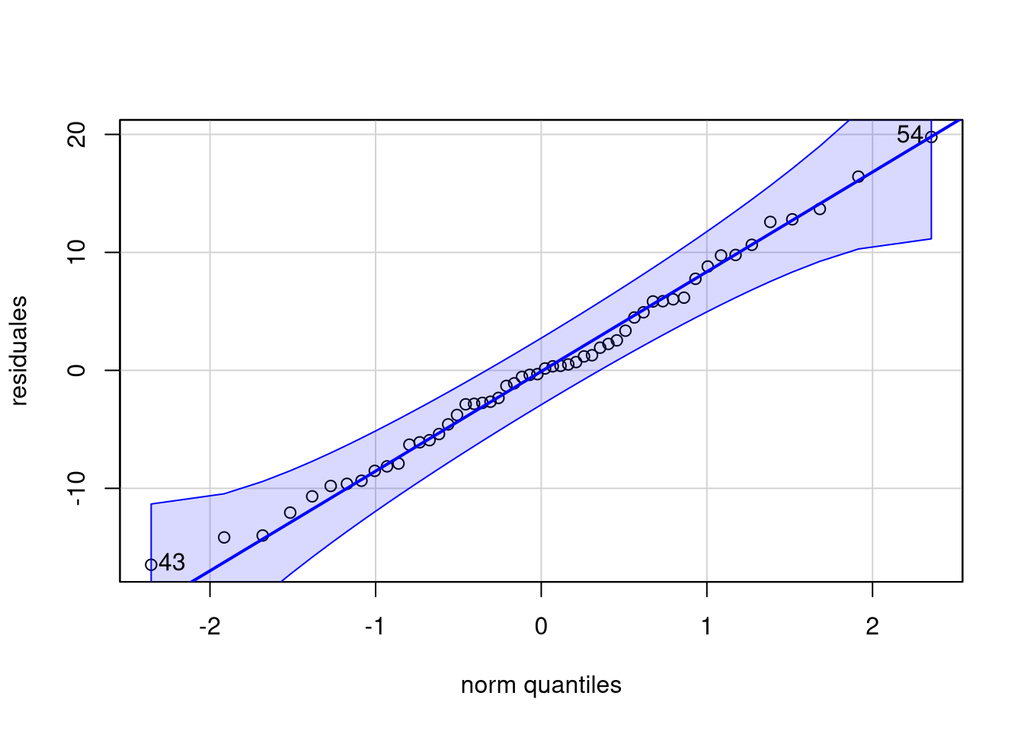

```
## [1] 54 43
```

```r
qqPlot(mod$res,ylab="residuales")
```

```r
library(lmtest)
bptest(modw,studentize=F)
```

```
##
##  Breusch-Pagan test
##
## data:  modw
## BP = 1159.8, df = 1, p-value < 2.2e-16
```

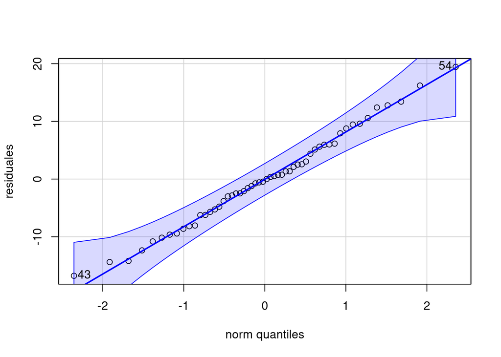

```
## [1] 54 43
```

```r
library(car)
qqPlot(modw$res,ylab="residuales")
```

Si las estimaciones de los coeficientes cuando se usaron ponderaciones difieren sustancialmente de los primeros coeficientes cuando no se ponderó, se sugiere iterar el proceso de ponderación usando los residuales de los mínimos cuadrados ponderados para volver a estimar la función de varianza o desviación estándar y luego obtener nuevos pesos. A menudo bastan una o dos iteraciones para estabilizar los coeficientes de regresión.

Cuando hay poca diferencia en las varianzas de los errores el método de mínimos cuadrados ponderados no es muy útil. El coeficiente de determinación $R^2$ no tiene un significado exacto, por lo que debe usarse con cautela.